# Week 9 R Exercise

## Load Libraries

```r
library(tidyverse)
library(janitor)
library(haven)
library(dplyr)
library(labelled)
library(ggplot2)
```

## Read Data

```r
all <- readRDS("../Data/all_data_updated.rds")
```

# Task 1: Building a Simple Linear Regression Model

```r
model <- lm(chol ~ bmi, data = all)



# Print summary

summary(model)
```

```
Call:
lm(formula = chol ~ bmi, data = all)

Residuals:
    Min      1Q  Median      3Q     Max
-109.13  -29.42   -3.31   24.04  358.11

Coefficients:
             Estimate Std. Error t value Pr(>|t|)
(Intercept) 180.70272    2.35418  76.758   <2e-16 ***
bmi           0.22436    0.07813   2.872   0.0041 **
---
Signif. codes:  0 ‘***’ 0.001 ‘**’ 0.01 ‘*’ 0.05 ‘.’ 0.1 ‘ ’ 1

Residual standard error: 41.69 on 5561 degrees of freedom
  (352 observations deleted due to missingness)
Multiple R-squared:  0.001481,  Adjusted R-squared:  0.001301
F-statistic: 8.246 on 1 and 5561 DF,  p-value: 0.0041
```

Coefficients = for each unit increase in BMI, cholestrol level rises by 0.22 mg/DL on average (slope) , expected cholestrol level when BMI=0 is 180.70272 (intercept)

R^2 value = 0.001481 = only 0.14% of of the variability in cholestrol levels is due to BMI, i.e. weak relationship

Significance of BMI as a predictor = 0.0041 i.e. statistically significant

# Task 2: Visualizing the Regression Line

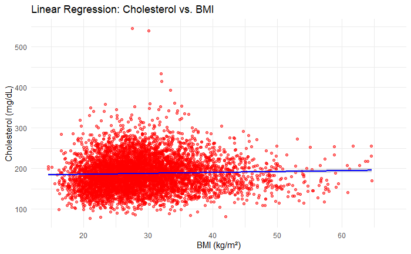

```r
# Scatter plot with regression line

ggplot(all, aes(x = bmi, y = chol)) +

  geom_point(color = "red", alpha = 0.5) +

  geom_smooth(method = "lm", se = TRUE, color = "blue") +

  labs(

    title = "Linear Regression: Cholesterol vs. BMI",

    x = "BMI (kg/m²)",

    y = "Cholesterol (mg/dL)"

  ) +

  theme_minimal()
```

# Task 3: Checking Assumptions

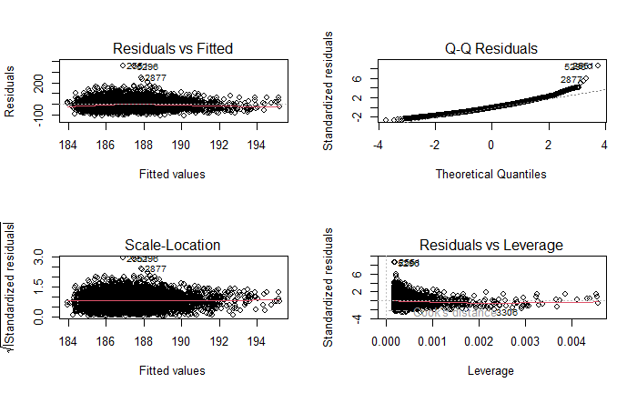

```r
# Diagnostic plots

par(mfrow = c(2, 2))  # Display 4 plots on one screen

plot(model)
```

Deviation is noticed in the Q-Q Plot, therefore this is not normally distributed.

The variance of the residuals in Residuals vs. Fitted Plot and Scale-Location Plot indicates heteroscedasticity.

# Task 4: Incorporating a Categorical Predictor

```r
# Filter data to remove NA values
all_filtered <- all %>% filter(!is.na(bmi), !is.na(chol), !is.na(smoking_status))



# Ensure smoking is treated as a factor
all_filtered$smoking <- as.factor(all_filtered$smoking_status)



# Fit a multiple linear regression model
smoking_model <- lm(chol ~ bmi + age + smoking_status, data = all_filtered)



# Print model summary
summary(smoking_model)
```

```
Call:
lm(formula = chol ~ bmi + age + smoking_status, data = all_filtered)

Residuals:
    Min      1Q  Median      3Q     Max
-112.72  -28.15   -3.00   23.22  355.99

Coefficients:
                      Estimate Std. Error t value Pr(>|t|)
(Intercept)          176.32375    3.00346  58.707   <2e-16 ***
bmi                    0.04604    0.08011   0.575    0.566
age                    0.27044    0.03228   8.378   <2e-16 ***
smoking_statusformer  -1.56629    1.82919  -0.856    0.392
smoking_statusnever   -1.98086    1.51538  -1.307    0.191
---
Signif. codes:  0 ‘***’ 0.001 ‘**’ 0.01 ‘*’ 0.05 ‘.’ 0.1 ‘ ’ 1

Residual standard error: 41.32 on 5260 degrees of freedom
Multiple R-squared:  0.01462,   Adjusted R-squared:  0.01387
F-statistic: 19.51 on 4 and 5260 DF,  p-value: 5.958e-16
```

## Interpretation of Coefficients

Intercept (176.32): This is the predicted cholesterol level for a reference individual who has a BMI of 0, is aged 0, and is in the “current smoker” category (the reference level for smoking_status). While not realistic as age and BMI cannot be 0, it serves as a baseline for comparison.

BMI (0.04604): For each 1-unit increase in BMI, cholesterol increases by 0.046 mg/dL on average, controlling for age and smoking status. However, this is not statistically significant (p=0.566p=0.566), indicating weak evidence of a relationship between BMI and cholesterol in this dataset.

Age (0.27044): For each 1-year increase in age, cholesterol increases by 0.27 mg/dL on average, controlling for BMI and smoking status. This relationship is statistically significant (p<0.001), suggesting a strong and positive association between age and cholesterol levels.

Smoking Status: “Former Smokers” (-1.57): Former smokers have, on average, 1.57 mg/dL lower cholesterol compared to current smokers, controlling for BMI and age. However, this difference is not statistically significant (p=0.392).

“Never Smokers” (-1.98): Never smokers have, on average, 1.98 mg/dL lower cholesterol compared to current smokers, controlling for BMI and age. Similarly, this difference is not statistically significant (p=0.191).

## Discussion of Differences

Current Smokers vs. Former and Never Smokers: The differences in cholesterol levels between current smokers and the other two groups (former and never smokers) are small and not statistically significant. This suggests that smoking status may not have a substantial or direct influence on cholesterol levels in this dataset, after accounting for BMI and age. However, the model does indicate slightly lower cholesterol levels for former and never smokers compared to current smokers.

The evidence is insufficient to draw strong conclusions about the relationship between smoking status and cholesterol in this dataset.

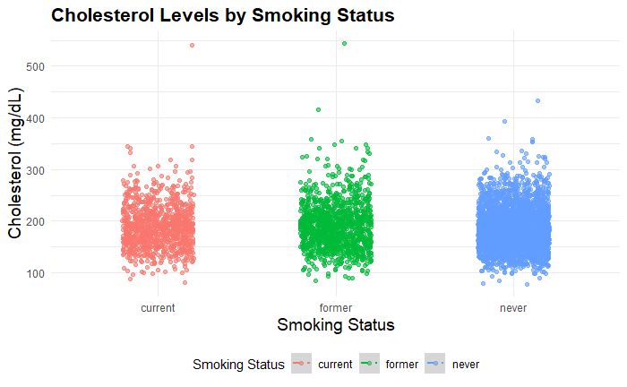

```r
# Create a jitter plot showing cholesterol distribution by smoking status
ggplot(data = all_filtered, aes(x = smoking_status, y = chol, color = smoking_status)) +
  geom_jitter(width = 0.2, alpha = 0.6) + # Jitter points to reduce overlap
  geom_smooth(method = "lm", aes(group = smoking_status), se = TRUE, linetype = "dashed") + # Add smooth line
  labs(
    title = "Cholesterol Levels by Smoking Status",
    x = "Smoking Status",
    y = "Cholesterol (mg/dL)",
    color = "Smoking Status"
  ) +
  theme_minimal() +
  theme(
    legend.position = "bottom",
    plot.title = element_text(size = 16, face = "bold"),
    axis.title = element_text(size = 14)
  )
```